# Popularity Prediction

New York Times Blog Articles

Philippe Lambot

May 4, 2020

## I. EXECUTIVE SUMMARY

This project is about predicting popularity of a set of blog articles. The objective is maximizing the ROC AUC, i.e. the Area Under the Curve of the Receiver Operating Characteristic (ROC) curve.

A rate of **94 % AUC** has been reached using **Natural Language Processing** and an **ensemble Machine Learning solution** combining eXtreme Gradient Boosting and Random Forest. Combination has been tested with ROC curves and AUCs on bootstrapped resamples.

TAGS: AUC, ROC, NLP, corpus, document term matrix, bag of words, ML, binary classification, eXtreme Gradient Boosting, Random Forest, bootstrapping, resamples, distributions, True Positive Rate (sensitivity), False Positive Rate, ensemble solution

GITHUB: https://github.com/Dev-P-L/NLP-Blog-Popularity-Prediction

## II. ACKNOWLEDGEMENTS

I would like to thank my friend Richard Careaga, former Associate General Counsel, JPMorgan Chase, N.A., for indefatigable questioning and discussion about domain, data science and editing. Interaction has been most supportive.

## III. FOREWORD to READERS

Dear Readers, you are most welcome to run the project on your own computer if you so wish.

This project is lodged with the GitHub repository https://github.com/Dev-P-L/NLP-Blog-Popularity-Prediction.

The project is based on a dataset of New York Times blog articles from the time period September 2014-November 2014. It originates from a Kaggle competition organized by the MIT in 2015.

For your convenience, the dataset has already been downloaded onto the GitHub repository wherefrom it will be automatically retrieved by the code from NLP_Popularity_Prediction_NYTimes.Rmd.

On your own computer, you can knit NLP_Popularity_Prediction_NYTimes.Rmd (please in HTML) and produce NLP_Popularity_Prediction_NYTimes.html, which can in turn be easily converted into e.g. NLP_Popularity_Prediction_NYTimes.oxps. On my laptop, running NLP_Popularity_Prediction_NYTimes.Rmd takes approximately two hours. For information, here are some characteristics of my work environment:

- R version 3.5.1 (2018-07-02) – “Feather Spray”,
- RStudio Version 1.1.456,
- Windows 10.

Some packages are required by NLP_Popularity_Prediction_NYTimes.Rmd. The code from NLP_Popularity_Prediction_NYTimes.Rmd contains commands to install these packages if they are not available yet.

## IV. GETTING IN TOUCH with DATA

The dataset is split into a validation set and a training set: the validation set contains one third of the rows from the original dataset, the training set two thirds.

Even if some categories (from e.g. *SectionName*) are populated in the validation set but not in the training set, the corresponding rows remain in the validation set. This might lower AUC a little bit on the validation set but in real-life prediction new data could indeed contain new categories.

Here is a description of the training set.

```
## 'data.frame':    4354 obs. of  10 variables:
##  $ NewsDesk      : Factor w/ 13 levels "","Business",..: 2 3 ...
##  $ SectionName   : Factor w/ 16 levels "","Arts","Business Day",..: 4 2 ...
##  $ SubsectionName: Factor w/ 9 levels "","Asia Pacific",..: 1 1 ...
##  $ Headline      : chr  "More School Daze" ...
##  $ Snippet       : chr  "A puzzle from Ethan Cooper that reminds me that a bill is due." ...
##  $ Abstract      : chr  "A puzzle from Ethan Cooper that reminds me that a bill is due." ...
##  $ WordCount     : int  508 285 ...
##  $ PubDate       : chr  "2014-09-01 22:00:09" ...
##  $ Popular       : Factor w/ 2 levels "Popular","Unpopular": 1 2 ...
##  $ UniqueID      : int  1 2 ...
```

There are ten features:

- one feature, i.e. “Popular”, contains labels (“Popular” or “Unpopular”),
- eight features are predictors,
- the last feature is an identifier.

There are 4354 observations.

Now, let’s perform exploratory data analysis, but only on the training set since no information from the validation set should contribute to modelling.

## V. EXPLORATORY DATA ANALYSIS (EDA)

### A. Prevalence of Positive Class

The positive class is “Popular”. Let’s have a look at the breakdown between positive and negative classes.

|  | Popular | Unpopular |
| --- | --- | --- |
| Training Set | 728 | 3 626 |

The positive class is clearly a minority, which justifies not relying on accuracy metric to measure predictive performance but on ROC AUC. Let’s calculate prevalence of the positive class.

|  | Prevalence of Positive Class (“Popular”) |
| --- | --- |
| Training Set | 17 % |

Prevalence of positive class is 17 %. Now, let’s turn to the group of classification predictors.

### B. Classification Predictors

#### 1. *News Desk*

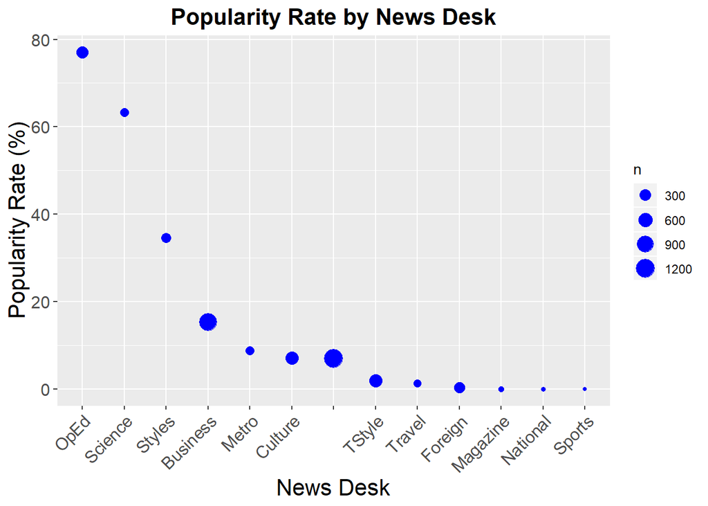

The categories with average popularity rate below 20 % predominate: there are more *news desk* groups below 20 % average popularity than above and they are altogether much more populated, with the undefined group containing at least 1,200 blog articles and the *business* group at least 900.

Nevertheless, three *news desks* stand out from the majority and have much higher average popularity rates; among them the *op-ed* group has an average popularity rate of almost 80 %. Moreover, the *op-ed* average popularity rate can be considered statistically representative with at least 300 blog articles. Let’s digitize information in the following table in order to get more precise information, among others about the numbers of blog articles in the *science* and *styles* categories.

| News Desk | Occurrence | Popularity Rate |
| --- | --- | --- |
| OpEd | 358 | 77.1 % |
| Science | 131 | 63.4 % |
| Styles | 194 | 34.5 % |
| Business | 1058 | 15.3 % |
| Metro | 136 | 8.8 % |
| Culture | 437 | 7.1 % |
|  | 1231 | 7 % |
| TStyle | 460 | 2 % |
| Travel | 76 | 1.3 % |
| Foreign | 255 | 0.4 % |
| Magazine | 14 | 0 % |
| National | 3 | 0 % |
| Sports | 1 | 0 % |

The categories *op-ed*, *science* and *styles* correspond to popularity rates of 77 %, 63 % and 35 % respectively and they can be considered statistically representative in terms of number of blog articles.

In contrast, *business*, *metro*, *culture* and the undefined category, which together contain a majority of blog articles, range between 15 % and 7 % in popularity rate.

The categories *tstyle*, *travel* and *foreign* have popularity rates of 2 % or lower.

The categories *magazine*, *national* and *sports* have a common popularity rate of 0 % but cannot be deemed to be statistically representative in terms of number of blog articles.

In a snapshot, this is a promising insight: *news desks* show some strong and statistically representative differences and they could have substantial predictive power.

It’s time now we turned to the *section name* predictor.

#### 2. *Section Name*

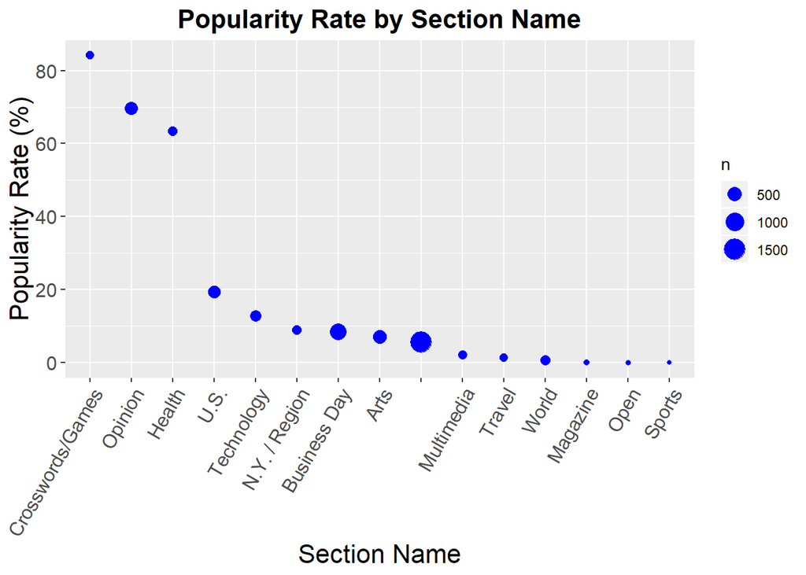

The graph above offers similarity with the graph about *news desks*: three categories have much higher popularity rates than the others. Let’s have a look at the corresponding table.

| Section Name | Occurrence | Popularity Rate |
| --- | --- | --- |
| Crosswords/Games | 82 | 84.1 % |
| Opinion | 411 | 69.6 % |
| Health | 131 | 63.4 % |
| U.S. | 340 | 19.4 % |
| Technology | 225 | 12.9 % |
| N.Y. / Region | 136 | 8.8 % |
| Business Day | 750 | 8.4 % |
| Arts | 437 | 7.1 % |
|  | 1500 | 5.7 % |
| Multimedia | 95 | 2.1 % |
| Travel | 77 | 1.3 % |
| World | 151 | 0.7 % |
| Magazine | 14 | 0 % |
| Open | 4 | 0 % |
| Sports | 1 | 0 % |

There is a clear-cut difference between some categories: *crosswords/games*, *opinion* and *health* have popularity rates above 60 %, much higher than other categories.

There might be some overlapping between some categories from *news desks* and some categories from *section names*: in the category *science* from *news desks*, there are 131 blog articles with an average popularity rate of 63 % and these statistics are exactly the same in the category *health* from *section names*…

But there are solid differences as well: among *news desks*, the categories above 63 % total 489 blog articles while, among *section names*, the categories above 63 % total 624 blog articles…

Consequently, without any further investigation, both predictors will be taken on board.

What about *subsection names*?

#### 3. *Subsection Name*

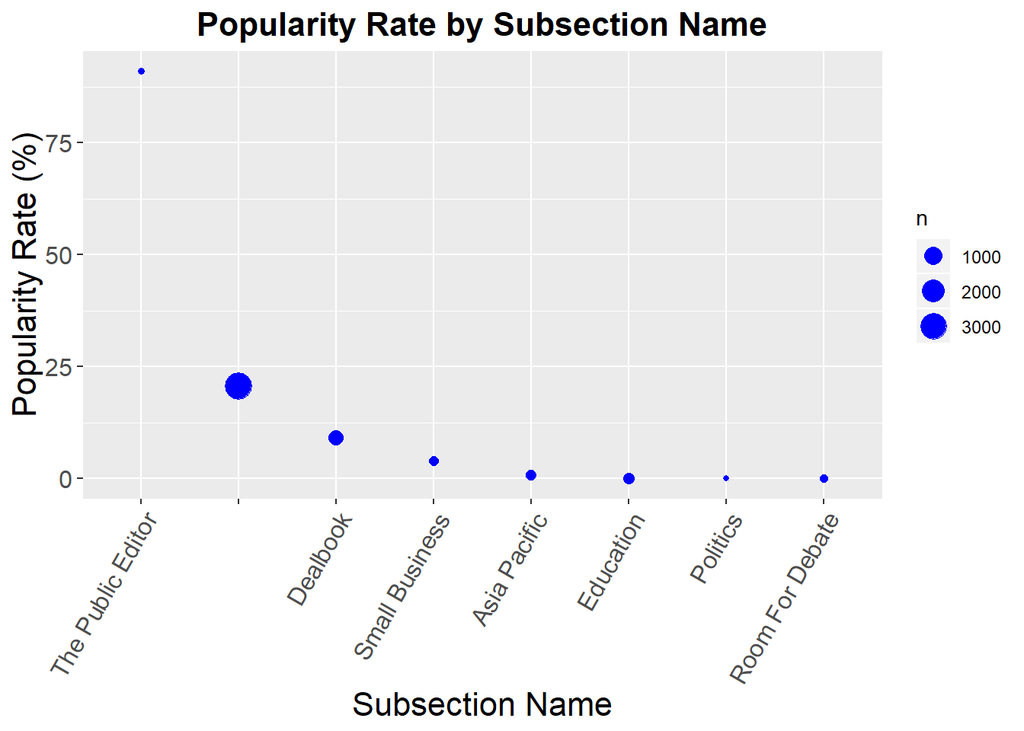

In the graph above, there is a very high popularity rate, but how many blog articles correspond to that rate?

| Subsection Name | Occurrence | Popularity Rate |
| --- | --- | --- |
| The Public Editor | 11 | 90.9 % |
|  | 3184 | 20.5 % |
| Dealbook | 650 | 9.1 % |
| Small Business | 100 | 4 % |
| Asia Pacific | 146 | 0.7 % |
| Education | 222 | 0 % |
| Politics | 2 | 0 % |
| Room For Debate | 39 | 0 % |

Actually, the popularity rate of 91 % is not really representative from a statistical point of view. But the rate of 21 % is well representative and rather distant from lower rates, and especially from the rates of *small business*, *Asia Pacific* and *education*.

Consequently, this insight makes us accept this predictor as well.

Up to now, three classification factors have been examined among candidate predictors. Pre-attentive insights have been garnered from graphs and precise information has been hoarded from tables. The three classification factors are kept as predictors.

The three following predictors are textual information: headlines, abstracts and snippets. Let’s start with a summary sample of headlines taken at random.

### C. Textual Predictors

#### 1. Headlines

|  | ILLUSTRATIVE SAMPLE OF HEADLINES |
| --- | --- |
| Training Set Row Number 1157 | Sky-High Rolling in Las Vegas |
| Training Set Row Number 1620 | 10 Ways to Explore and Express What Makes Your Community Unique |
| Training Set Row Number 2494 | Globalfest 2015 Will Offer a Broad View of World Music |

These three examples of headlines show, as expected, very tidy text. After this insight, we can dispense with some corrective measures in Natural Language Processing.

Let’s now turn to the corresponding random sample of abstracts.

#### 2. Abstracts

|  | ILLUSTRATIVE SAMPLE OF ABSTRACTS |
| --- | --- |
| Training Set Row Number 1157 | The High Roller in Las Vegas gives visitors an opportunity to celebrate above it all. |
| Training Set Row Number 1620 | What communities are you a part of? Which one matters to you most? What do people need to know about this community? How can you communicate that? Here are some ideas for projects for teachers and stu… |
| Training Set Row Number 2494 | The one-day festival, now in its 12th year, will bring together musical styles from all corners of the globe in January. |

Just as the random sample of headlines, this random sample of abstracts shows cleanness. The last piece of textual information consists of snippets.

#### 3. Snippets

|  | ILLUSTRATIVE SAMPLE OF SNIPPETS |
| --- | --- |
| Training Set Row Number 1157 | The High Roller in Las Vegas gives visitors an opportunity to celebrate above it all. |
| Training Set Row Number 1620 | What communities are you a part of? Which one matters to you most? What do people need to know about this community? How can you communicate that? Here are some ideas for projects for teachers and stu… |
| Training Set Row Number 2494 | The one-day festival, now in its 12th year, will bring together musical styles from all corners of the globe in January. |

The first and the third snippets are exactly the same as the corresponding abstracts, but, interestingly enough, the second one is a shortened version of the corresponding abstract, whose last words have been dropped. After some checking, it appears that some other abstracts have been shortened as well. How many snippets differ from abstracts because some words have been dropped at the end?

```r
# Building up a response vector registering the snippets that differ.
v <- as.logical(rep("FALSE", length(trainNews$Snippet)))
for (i in 1:length(trainNews$Snippet)) {
  v[i] <- identical(as.character(trainNews$Snippet[i]),
                    as.character(trainNews$Abstract[i]))
}

# Calculating the number of snippets that differ from corresponding abstracts.
nr_dif <- as.integer(sum(v == FALSE))

# Calculating the proportion of snippets that differ from abstracts.
prop_dif <- paste(round((nr_dif / length(v)) * 100, 1), "%", sep = " ")
```

Let’s visualize results.

|  | SNIPPETS DIFFERING FROM ABSTRACTS |
| --- | --- |
| Number in Training Set | 62 |
| Proportion in Training Set | 1.4 % |

Snippets differing from abstracts are a very small minority. The vast majority of snippets are strictly identical to abstracts. Consequently, only one out of the two predictors will be kept. Which one will it be? Preference will be given to snippets because they might impact more on readers.

Let’s now examine a numerical predictor: word count.

### D. Numerical Predictor: Word Count

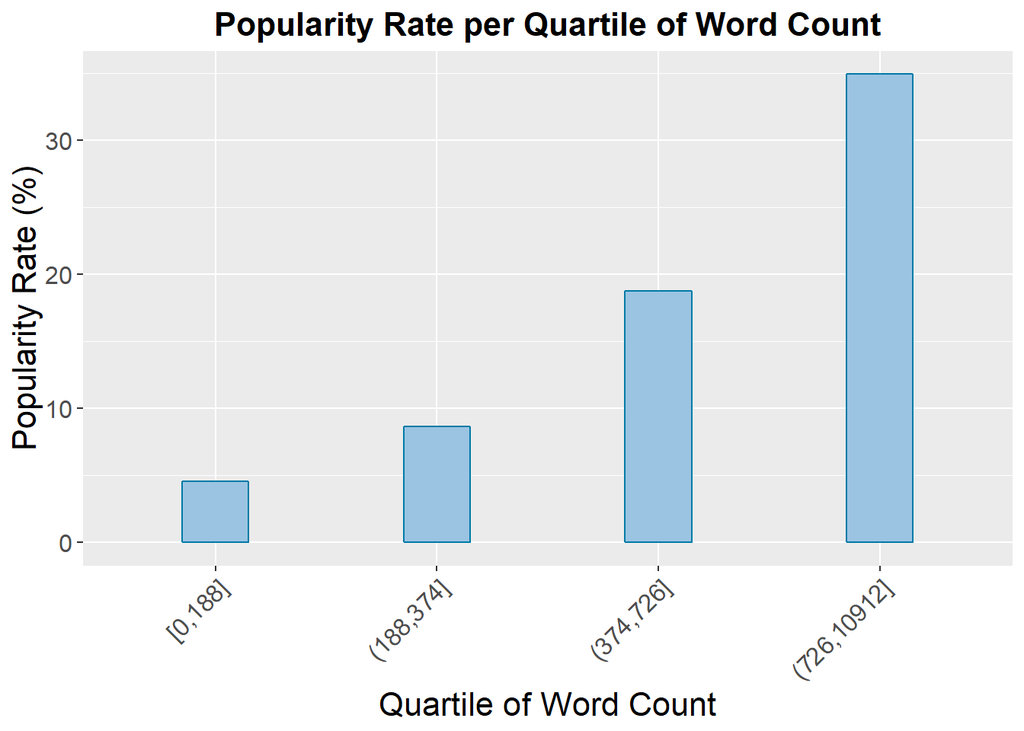

The graph above is insightful: measured per quartile of word count, popularity rate is strictly and substantially increasing with word count. Moreover, differences are statistically significant since each average popularity rate refers to approximately one fourth of the training set. Consequently, word count will be used as a predictor in Machine Learning.

The next group of predictors contains temporal patterns.

### E. Temporal Predictors

In the training set, the feature *PubDate* is a time series indicating date and time of publication of blog articles, including year, month, day, hour, minute and second. Let’s decompose this time series and extract several components

Year is not helpful here since there is no variation: all blog articles are from 2014.

Month can be interesting: there are three of them, from September until November.

Two additional temporal patterns will be extracted: day of the week and hour in a 24-hour clock system.

```r
temp <- trainNews %>%
  mutate(date = as.POSIXct(PubDate)) %>%
  mutate(weekday = weekdays(date, abbreviate = TRUE)) %>%
  mutate(month = month(date, label = TRUE)) %>%
  mutate(hour = hour(date)) %>%
  mutate(y = y_train)
```

#### 1. Average Popularity Rate per Month

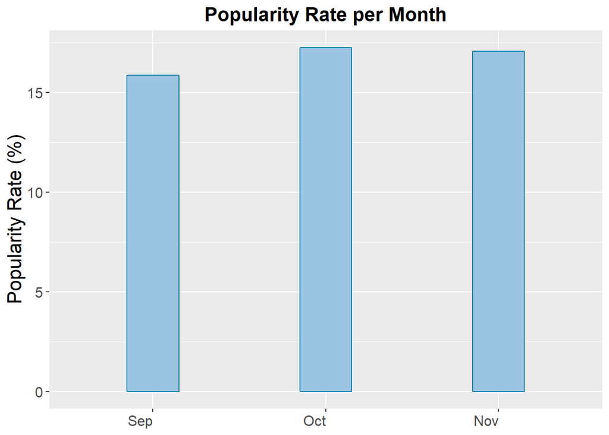

Differences per month being Lilliputian, this predictor will not be added to the training set. Let’s now have a try with weekdays.

#### 2. Average Popularity Rate per Weekday

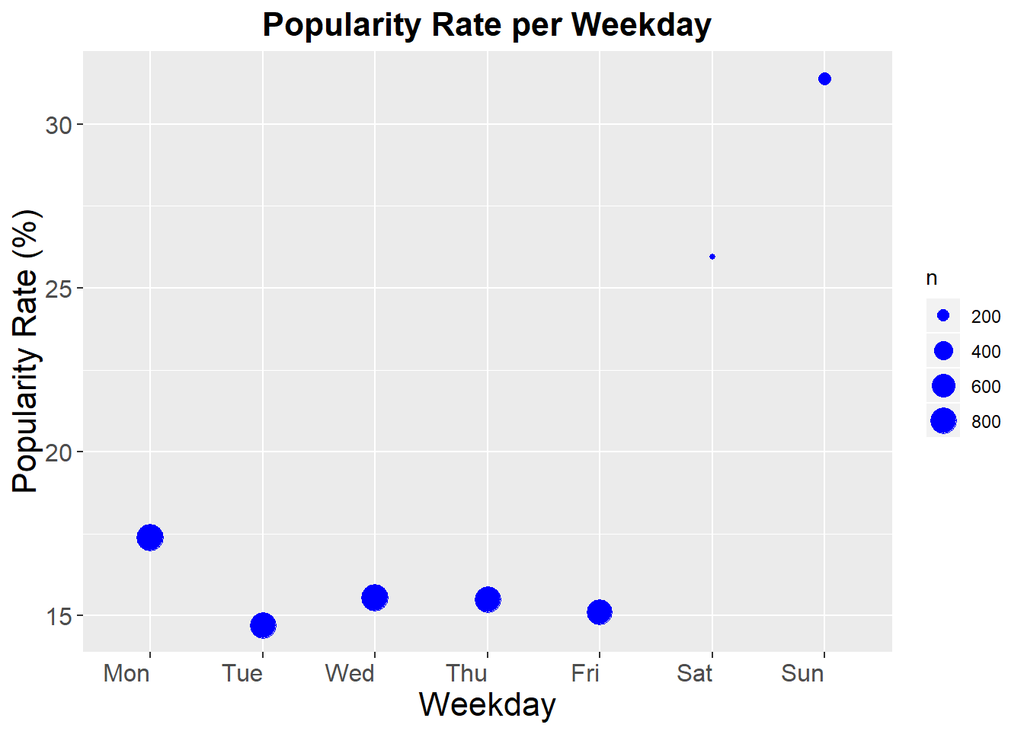

There is a clear difference between weekend and weekdays outside weekends: average popularity rate is substantially higher during weekend, and especially on Sundays. But are these higher rates statistically representative? It is representative for Sunday, with at least 200 blog articles. But what about Saturday?

| Weekday | Occurrence | Popularity Rate |
| --- | --- | --- |
| Sun | 207 | 31.4 |
| Sat | 131 | 26.0 |
| Mon | 834 | 17.4 |
| Wed | 850 | 15.5 |
| Thu | 788 | 15.5 |
| Fri | 742 | 15.1 |
| Tue | 802 | 14.7 |

Saturday’s higher popularity rate is also considered statistically significant with 131 blog articles.

#### 3. Average Popularity Rate per Hour

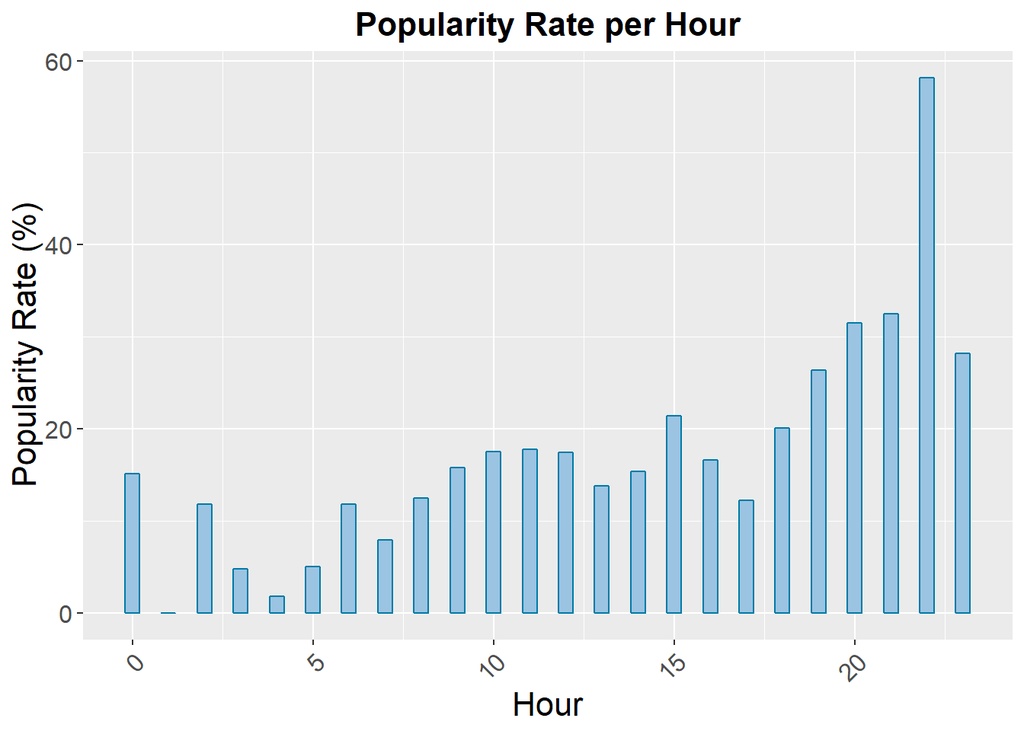

There is an upward tendency in a 24-hour clock presentation: popularity rate is rather low between 1 a.m. and 5 a.m., then rises especially from 7 p.m. onwards, culminating at almost 60 % in the 10 p.m. period.

But are the lowest and highest average popularity rates statistically representative? Let’s have a look at a breakdown of observations per hour in a 24-hour clock presentation.

| Hour | Occurrence | Popularity Rate |
| --- | --- | --- |
| 22 | 98 | 58.2 % |
| 21 | 77 | 32.5 % |
| 20 | 111 | 31.5 % |
| 23 | 39 | 28.2 % |
| 19 | 129 | 26.4 % |
| 15 | 290 | 21.4 % |
| 18 | 209 | 20.1 % |
| 11 | 337 | 17.8 % |
| 10 | 257 | 17.5 % |
| 12 | 344 | 17.4 % |
| 16 | 295 | 16.6 % |
| 9 | 222 | 15.8 % |
| 14 | 293 | 15.4 % |
| 0 | 86 | 15.1 % |
| 13 | 297 | 13.8 % |
| 8 | 241 | 12.4 % |
| 17 | 254 | 12.2 % |
| 2 | 17 | 11.8 % |
| 6 | 152 | 11.8 % |
| 7 | 254 | 7.9 % |
| 5 | 179 | 5 % |
| 3 | 42 | 4.8 % |
| 4 | 113 | 1.8 % |
| 1 | 18 | 0 % |

Observations are more concentrated in the middle of the empirical distribution. Nevertheless, even extreme rates are statistically representative; this is the case for the highest rate of almost 60 %; this is also the case for the lowest rates below 5 % if they are considered together. Consequently, this predictor will also be included into the training set.

This concludes our EDA. Let’s go on with some data profiling. Two predictors will be added to the training set: “weekday”" (days of the week) and “hour” (hour in a 24-hour clock). Moreover, textual information will be processed through NLP.

## VI. NATURAL LANGUAGE PROCESSING

The following transformations will be performed on the training set:

- for each training set observation, headline and snippet will be amalgamated;
- a corpus will be built;
- letters will be lowercased;
- punctuation marks will be removed;
- stopwords (from the function stopwords()) will be removed;
- words will be stemmed;
- sentences will be tokenized into stemmed words in a Document Term Matrix;
- sparsity management will only keep tokens appearing in headlines or snippets from at least 2.5 % of blog articles.

```r
# Combining headlines and snippets.
v <- 1:nrow(trainNews)
for (i in 1:nrow(trainNews)) {
  v[i] <- paste(trainNews$Headline[[i]],
                trainNews$Snippet[[i]], sep = " ")
}

# Corpus is created on training reviews only to avoid any interference
# between training reviews and validation reviews. Otherwise,
# tokens from validation set could (at least slightly) impact
# on token selection when applying the sparsity threshold.
corpus <- VCorpus(VectorSource(v))

# Lowercasing, removing punctuation and stopwords, stemming.
corpus <- tm_map(corpus, content_transformer(tolower))
corpus <- tm_map(corpus, removePunctuation)
corpus <- tm_map(corpus, removeWords, stopwords("english"))
corpus <- tm_map(corpus, stemDocument)

# Building up a bag of words in a Document Term Matrix.
dtm <- DocumentTermMatrix(corpus)

# Managing sparsity with sparsity threshold.
sparse <- removeSparseTerms(dtm, 0.975)

# Converting the Document Term Matrix into matrix and then into a data frame.
sentSparse <- as.data.frame(as.matrix(sparse))

# Making all column names R-friendly.
colnames(sentSparse) <- make.names(colnames(sentSparse))

rm(v, i, corpus, dtm, sparse)
```

Let’s have a look at a word cloud based on the bag of words to get some pre-attentive insights.

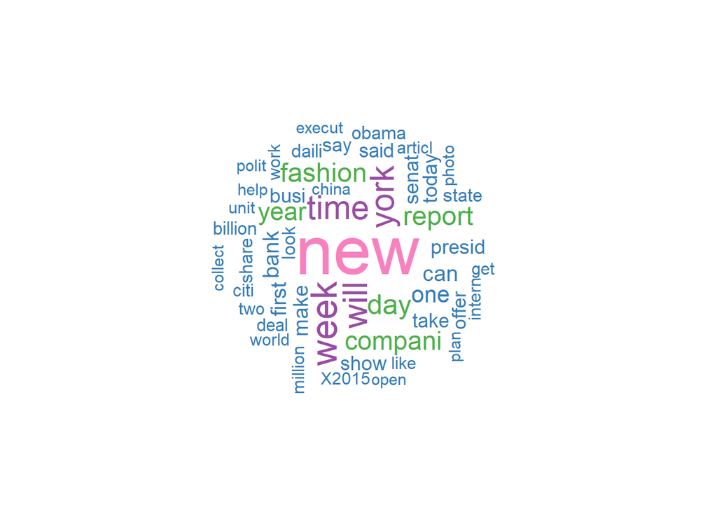

```r
set.seed(1)
wordcloud(colnames(sentSparse), colSums(sentSparse), min.freq = 1,
          max.words = 50, random.order = FALSE, rot.per = 1/3,
          colors = brewer.pal(8, "Set1"), scale = c(4,.5))
```

In the word cloud above, we can see tokens such as *fashion*, *obama*, *presid*, *senat*, *billion*, *bank*, *million*, *work*, etc.

Let’s add the columns from the Document Term Matrix to the training set and proceed to Machine Learning prediction of popularity.

## VII. MACHINE LEARNING PREDICTION on the TRAINING SET with XGB and RF

```r
fitControl <- trainControl(classProbs = TRUE,
                           ## Evaluating performance using
                           ## the following function.
                           summaryFunction = twoClassSummary,
                           returnResamp = "all",
                           savePredictions = "all")

set.seed(1)
fit_xgb <- train(Popular ~ ., data = train,
                 method = "xgbLinear",
                 trControl = fitControl,
                 ## Specifying which metric to optimize.
                 metric = "ROC")

set.seed(1)
fit_rf <- train(Popular ~ ., data = train,
                 method = "rf",
                 trControl = fitControl,
                 ## Specifying which metric to optimize.
                 metric = "ROC")

rm(fitControl)
```

Let’s compare merits from RF and XGB. It is only fitting that the first examined objects are the respective ROC curves and ROC AUCs. Let’s start with XGB.

```r
fitted_xgb_prob <- predict(fit_xgb, type = "prob")
roc_xgb <- roc(as.factor(train$Popular), fitted_xgb_prob$Popular,
               quiet = TRUE)
```

Here is the AUC polygon graph from XGB.

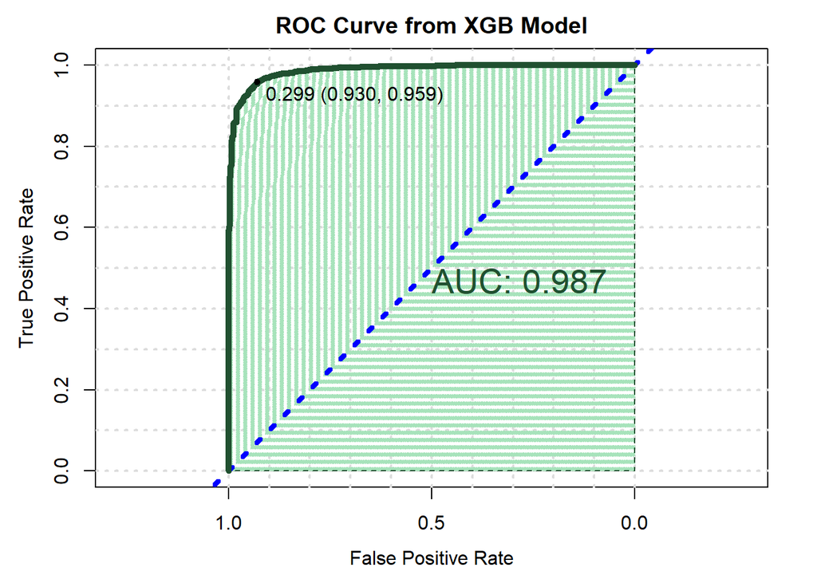

The true positive rate immediately jumps to almost 1 and rapidly reaches 1 to remain there. The AUC is impressive with 99 % but it is calculated on the training set and not on the validation set. Now, let’s turn to RF.

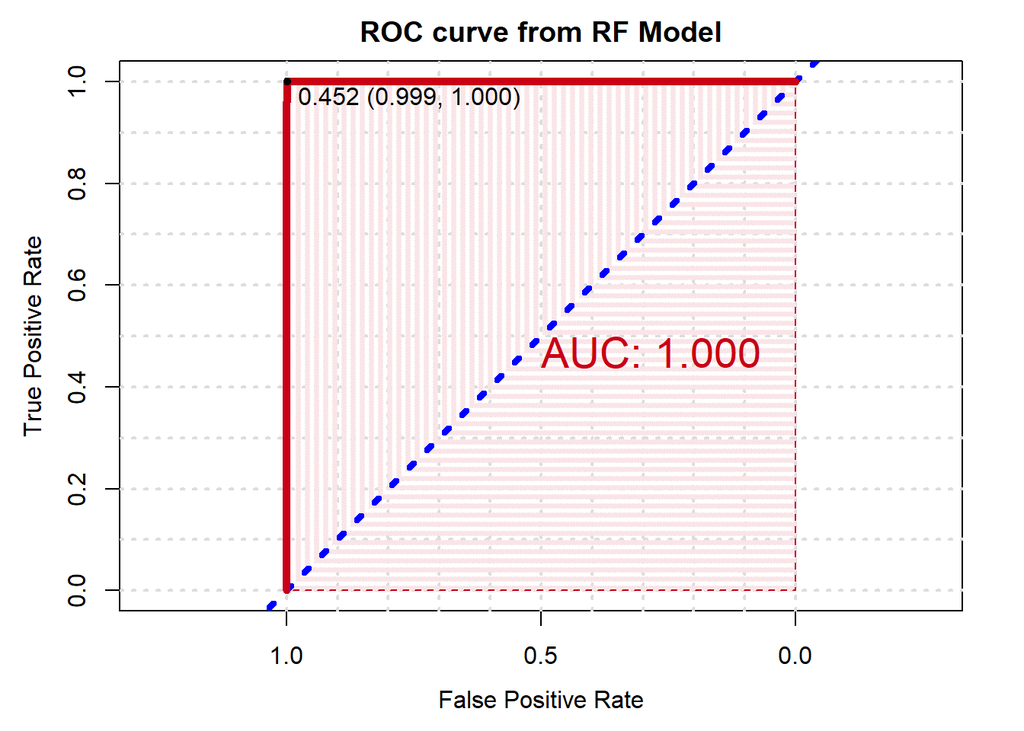

This is the perfect ROC curve and AUC. The true positive rate immediately jumps to 1 and remains at that level; the AUC polygon is a perfect square of 1 X 1 and the AUC is the maximum, i.e. 100 %; but, once again, this is prediction on the training set and not on the validation set.

Overfitting is very probable, in the case of RF but even in the case of XGB.

How could overfitting be estimated? Among RF and XGB, Which is the best model to predict on the validation set? Or should we move to another model?

In order to answer these questions, let’s make the most of unused information about bootstrapped resample distributions.

## VIII. TESTING XGB and RF on BOOTSTRAPPED RESAMPLE DISTRIBUTIONS

In the train() function from the package caret, the default methods have been kept: parameters are tuned across three values and resampling is done on 25 bootstrapped resamples. In the XGB model, there have been 675 AUC estimates: indeed, there are 27 combinations of parameter values (3 values for the parameter *lambda*, 3 for the parameter *alpha* and 3 again for the parameter *nrounds*) and each combination is run on 25 bootstrapped resamples. In the RF model, there have been 75 AUC estimates: 3 values for the parameter *mtry*, each of them being run on 25 bootstrapped resamples.

Looking at these AUC estimates might deliver insights about overfitting and performance transposability to the validation set.

### A. All resample AUCs

Let’s get started with a quick summary statistic per model, which is calculated across all AUCs per model, i.e. across 675 AUCs for XGB and 75 AUCs for R. This summary statistic gives

- the minimum of all AUCs per model,
- the mean of all AUCs per model
- and the maximum of all AUCs per model.

|  | Minimum Resample AUC | Average Resample AUC | Maximum Resample AUC |
| --- | --- | --- | --- |
| eXtreme Gradient Boosting Model | 90.34 | 92.60 | 94.58 |
| Random Forest Model | 89.12 | 91.34 | 94.53 |

The table above delivers two insights.

First, AUC levels are substantially lower than the 100 % and 99 % of the final models, whose results have been shown previously. This insight tends to ascertain the hypothesis of overfitting.

Second, order in performance metric has been reversed: while RF delivers a perfect AUC of 100 % on the final model and slightly surpasses XGB, on resamples RF is slightly outperformed by XGB. This is especially so in minimum AUC and in average AUC.

### B. AUCs Regrouped according to Parameterization

Let’s regroup AUCs according to parameterization.

27 density functions will be drawn for XGB, i.e. one per each of the 27 combinations of parameter values; 3 density functions will be produced for RF, i.e. one per each of the 3 parameter values tuned on RF. Here are the XGB density functions.

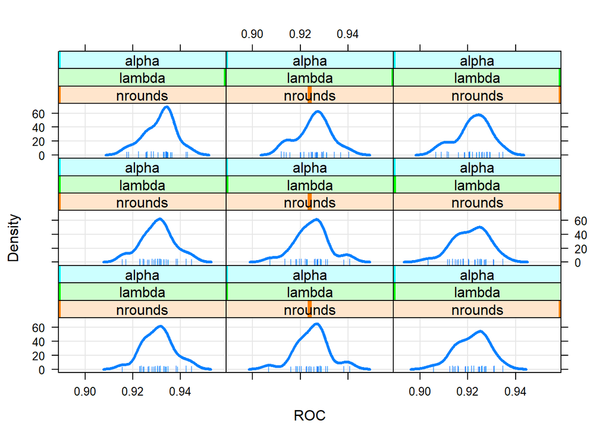

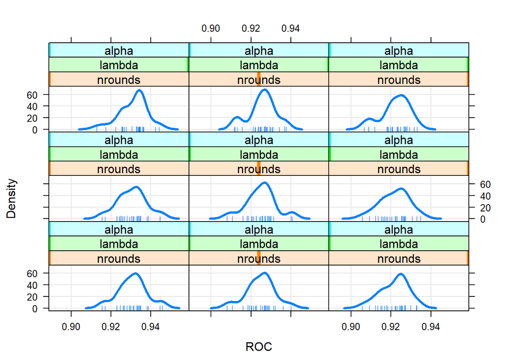

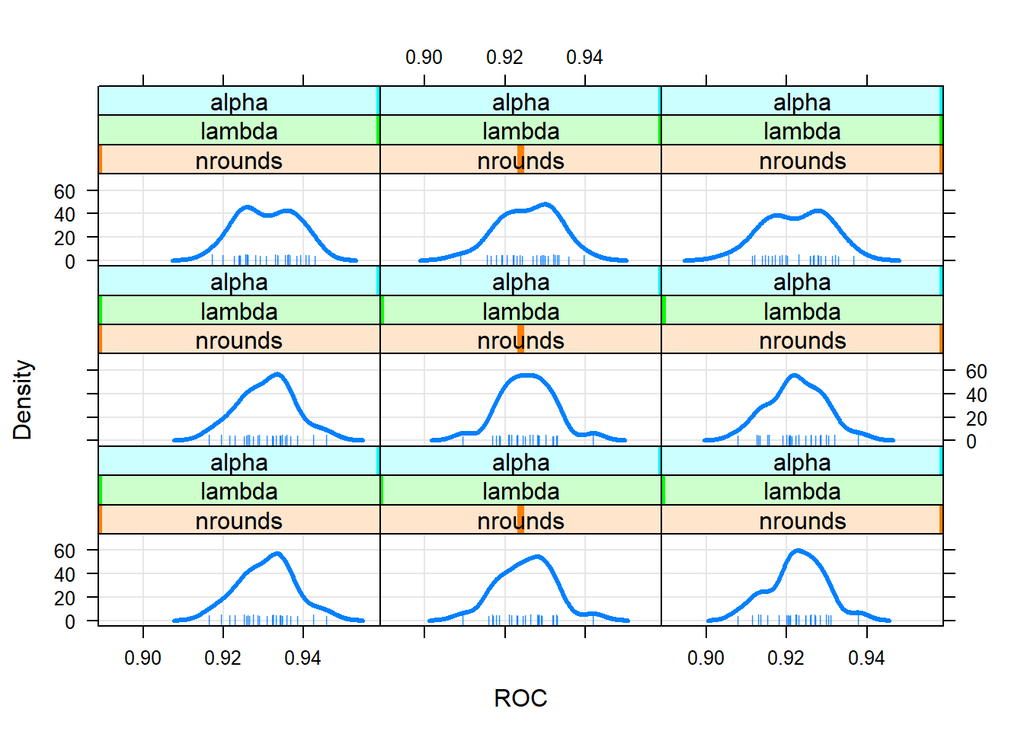

```r
densityplot(fit_xgb, pch = "|", lwd = 3, grid = T, ylab = "Density")
```

The top of the density functions is above 92 % ROC AUC in the 27 cases. Let’s turn to the RF density functions.

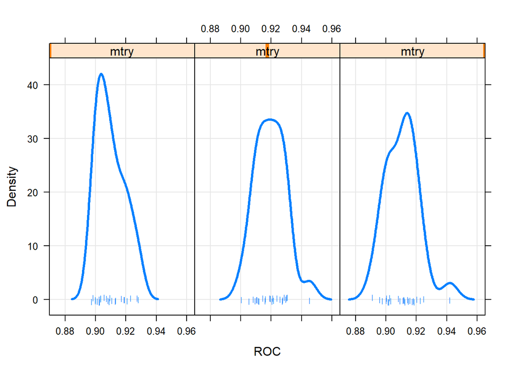

```r
densityplot(fit_rf, pch = "|", lwd = 3, grid = T, ylab = "Density")
```

In two cases out of three, the top of the density function (and the main part of it as well) is below 92 %. In one case out of three, the top almost reaches 92 %. This contrasts with XGB having the top of its 27 density functions above 92 %.

For each density function, the average AUC (over 25 resamples) will be calculated and the following table will give the range between the minimum AUC and the maximum AUC per model; consequently, for model XGB, it will be a range over 27 average AUCs and, for model RF, it will be the range over 3 average AUCs.

```r
density_xgb <- fit_xgb$results %>%
  summarise(range = paste(min = round((min(ROC) * 100), 2),
                          max = round((max(ROC) * 100), 2),
                          sep = " - ")) %>%
  select(range)

density_rf <- fit_rf$results %>%
  summarise(range = paste(min = round((min(ROC) * 100), 2),
                          max = round((max(ROC) * 100), 2),
                          sep = " - ")) %>%
  select(range)
```

The ranges are as follows.

|  | RANGE of AUCs AVERAGED according to PARAMETERIZATION |
| --- | --- |
| eXtreme Gradient Boosting Model | 92.13 - 93.13 |
| Random Forest Model | 90.98 - 91.95 |

The XGB range lies somewhat higher than the RF range. This is an additional insight towards the hypothesis of XGB performing somewhat better in this project.

### C. AUCs Corresponding to Optimal Parameterization

From the ranges calculated above, let’s extract, for each model, the AUC corresponding to the optimal parameter value(s).

```r
stat <- summary(resamples(list(fit_xgb, fit_rf)))
tab <- round((stat$statistics$ROC[7:8] * 100), 2)
rm(stat)
```

Here is the comparative table with AUCs corresponding to the optimal parameter value(s).

|  | RESAMPLE AUC with OPTIMAL PARAMETERIZATION |
| --- | --- |
| eXtreme Gradient Boosting Model | 93.13 |
| Random Forest Model | 91.95 |

XGB scores an AUC of 93 % versus an AUC of 92 % for RF.

### D. Taking Stock of XGB and RF Results on Bootstrapped Resamples

The table above is the last step in our evaluating the predictive power of the XGB and RF models thanks to bootstrapped resample information.

First, AUCs have been collected on the 675 resamples from XGB and the 75 resamples from RF. Second, AUCs have been regrouped according to parameterization, with 27 parameter value combinations for XGB and 3 parameter values for RF. Third, from these regroupments only AUCs corresponding to optimal parameterization have been kept in the table above. In the three steps, XGB has proved a little more performing in AUC.

At this stage, XGB should be the model to be validated on the validation set.

But AUC has dramatically dropped with respect to the the AUCs from the final models on the training set. Instead of being at 100 % or 99 %, AUC is now at 93-92 % on resamples and this lower level is most probably closer to predictive capability on the validation set. This drop in AUC looks like a stimulus to further modelling towards AUC optimization.

## IX. TESTING ENSEMBLE SOLUTION on BOOTSRAPPED RESAMPLE DISTRIBUTIONS

That is exactly what will be tried. An ensemble solution will be built by combining probabilities of the positive class originating from the two individual models: for each blog article, popularity will be predicted using the average of the probabilities produced respectively by XGB and RF.

Before opting into validating the ensemble solution on the validation set, the predictive power of the ensemble solution will be tested on the bootstrapped resamples.

```r
# Retrieving optimal parameter values.
bt_xgb <- fit_xgb$bestTune
bt_rf <- fit_rf$bestTune

# Getting probabilities of the positive class with optimal parameterization and average on the 25 bootstrapped resamples.
df_xgb <- fit_xgb$pred %>%
          as.data.frame(stringsAsFactors = FALSE) %>%
          filter(lambda == bt_xgb$lambda,
                 alpha == bt_xgb$alpha,
                 nrounds == bt_xgb$nrounds) %>%
          group_by(rowIndex) %>%
          summarize(prob_popular = mean(Popular)) %>%
          select(rowIndex, prob_popular)

df_rf <- fit_rf$pred %>%
         as.data.frame(stringsAsFactors = FALSE) %>%
         filter(mtry == bt_rf$mtry) %>%
         group_by(rowIndex) %>%
         summarize(prob_popular = mean(Popular)) %>%
         select(rowIndex, prob_popular)

# Calculating mean of XGB probability and RF probability for each observation.
prob_popular_ensemble <- (df_xgb$prob_popular + df_rf$prob_popular) / 2

# ROC function of the ensemble solution
ro <- roc(as.factor(train$Popular), prob_popular_ensemble)

# AUC of the ensemble solution
auc_ensemble <- round((auc(ro) * 100), 2)
```

Let’s have a look at the AUC produced by the ensemble solution, compared with AUCs from XGB and RF.

|  | RESAMPLE AUC with OPTIMAL PARAMETERIZATION |
| --- | --- |
| Random Forest Model | 91.95 |
| eXtreme Gradient Boosting Model | 93.13 |
| Ensemble Solution XGB + RF | 93.93 |

On the basis of bootstrapped resamples, the most performing model in AUC is the ensemble solution, which will be tentatively validated on the validation set.

## X. VALIDATION on the VALIDATION SET

The training set has been built up completely separately, to avoid any interaction with the validation set, which will be constructed now.

```r
valNews <- valNews %>%
  mutate(date = as.POSIXct(PubDate)) %>%
  mutate(weekday = weekdays(date, abbreviate = TRUE)) %>%
  mutate(hour = hour(date)) %>%
  as.data.frame(stringsAsFactors = FALSE) %>%
  select(- PubDate, - date, - Abstract, - UniqueID)

# Combining headlines and snippets.
v <- 1:nrow(valNews)
for (i in 1:nrow(valNews)) {
  v[i] <- paste(valNews$Headline[[i]],
                valNews$Snippet[[i]], sep = " ")
}

# Corpus is created on training reviews only to avoid any interference
# between training reviews and validation reviews. Otherwise,
# tokens from validation set could (slightly) impact on token selection
# when applying the sparsity threshold.
corpus <- VCorpus(VectorSource(v))

# Lowercasing, removing punctuation and stopwords, stemming document.
corpus <- tm_map(corpus, content_transformer(tolower))
corpus <- tm_map(corpus, removePunctuation)
corpus <- tm_map(corpus, removeWords, stopwords("english"))
corpus <- tm_map(corpus, stemDocument)

# Building up a bag of words in a Document Term Matrix.
dtm <- DocumentTermMatrix(corpus)

# Managing sparsity with sparsity threshold.
sparse <- removeSparseTerms(dtm, 0.975)

# Converting sparse, which is a DocumentTermMatrix,
# to a matrix and then to a data frame.
sentSparse <- as.data.frame(as.matrix(sparse))

# Making all column names R-friendly.
colnames(sentSparse) <- make.names(colnames(sentSparse))

# For machine learning, columns have to match between training set
# and validation set: adjustments have to be made on the validation set.

# Let's keep only columns that alo exist in the training set.
sentSparse <- sentSparse %>% as.data.frame() %>%
  select(intersect(colnames(.), colnames(sentSparse_train)))

# Columns from train that are missing in val have to be added as null vectors.
mis <- setdiff(colnames(sentSparse_train), colnames(sentSparse))
df <- data.frame(matrix((nrow(sentSparse) * length(mis)),
                 nrow = nrow(sentSparse), ncol = length(mis)) * 0) %>%
      `colnames<-`(mis)
buffer <- cbind(sentSparse, df) %>% as.data.frame()

val <- cbind(valNews, buffer) %>% select(- Headline, - Snippet)

rm(corpus, dtm, sparse, sentSparse, sentSparse_train, valNews)
rm(v, i, mis, df, buffer)
```

On the validation set, the model XGB, the model RF and the ensemble solution will be run.

```r
# On the validation set, predicting with XGB, calculating ROC curve and AUC.
pred_xgb <- predict(fit_xgb, newdata = val, type = "prob")
roc_xgb <- roc(as.factor(val$Popular), pred_xgb$Popular)
auc_xgb <- round((auc(roc_xgb) * 100), 2)

# On the validation set, predicting with RF, calculating ROC curve and AUC.
pred_rf <- predict(fit_rf, newdata = val, type = "prob")
roc_rf <- roc(as.factor(val$Popular), pred_rf$Popular)
auc_rf <- round((auc(roc_rf) * 100), 2)

# On the validation set, predicting with the ensemble solution, calculating ROC curve and AUC.
hope <- data.frame(Popular = (pred_xgb$Popular + pred_rf$Popular) / 2)
roc_ens <- roc(as.factor(val$Popular), hope$Popular)
auc_ens <- round((auc(roc_ens) * 100), 2)
```

The following table shows the AUC for XGB, RF and the ensemble solution.

|  | AUC on the VALIDATION SET |
| --- | --- |
| Random Forest Model | 92.90 |
| eXtreme Gradient Boosting Model | 93.11 |
| Ensemble Solution XGB + RF | 93.75 |

Predictions on the validation set are close to predictions on bootstrapped resamples with optimal parameterization: ranking is the same, AUC level is similar for XGB and the ensemble solution and one percentage point higher for Random Forest.

In predictions on the validation set, the individual models XGB and Random Forest deliver a 93 % AUC level of the ROC curve; the ensemble solution combining XGB and Random Forest produces a 94 % AUC level.

## XI. REFERENCES

Links have been checked on May 4, 2020.

### A. News Popularity Prediction

https://www.researchgate.net/publication/306061597_Predicting_the_Popularity_of_News_Articles

file:///C:/Users/Acer/Downloads/PAA_ModellingAndPredictingNewsPopularity_13112012.pdf

file:///C:/Users/Acer/Downloads/4646-21907-1-PB.pdf

https://minimaxir.com/2017/06/reddit-deep-learning/

https://medium.com/@syedsadiqalinaqvi/predicting-popularity-of-online-news-articles-a-data-scientists-report-fac298466e7

### B. ROC Curves and AUC

https://topepo.github.io/caret/model-training-and-tuning.html#alternate-performance-metrics

https://datascience.stackexchange.com/questions/806/advantages-of-auc-vs-standard-accuracy

Xavier Robin, Natacha Turck, Alexandre Hainard, Natalia Tiberti, Frédérique Lisacek, Jean-Charles Sanchez and Markus Müller (2011). “pROC: an open-source package for R and S+ to analyze and compare ROC curves”. BMC Bioinformatics, 12, p. 77. DOI: 10.1186/1471-2105-12-77

https://cran.r-project.org/web/packages/pROC/pROC.pdf

https://stackoverflow.com/questions/30366143/how-to-compute-roc-and-auc-under-roc-after-training-using-caret-in-r

https://www.rdocumentation.org/packages/pROC/versions/1.16.2/topics/roc

https://www.rdocumentation.org/packages/pROC/versions/1.16.2/topics/plot.roc

### C. Resampling and Distributions

https://rafalab.github.io/dsbook/machine-learning-in-practice.html#exercises-55

https://www.rdocumentation.org/packages/caret/versions/6.0-86/topics/trainControl

https://www.rdocumentation.org/packages/lattice/versions/0.3-1/topics/densityplot